# Gather Data

```python
twitter_archive_df_clean
```

|  | tweet_id | in_reply_to_status_id | in_reply_to_user_id | timestamp | source | text | expanded_urls | rating_numerator | rating_denominator | name | dog_stage |
| --- | --- | --- | --- | --- | --- | --- | --- | --- | --- | --- | --- |
| 0 | 892420643555336193 | NaN | NaN | 2017-08-01 16:23:56 | Twitter for iPhone | This is Phineas. He's a mystical boy. Only eve... | https://twitter.com/dog_rates/status/892420643... | 13 | 10 | Phineas | NaN |
| 1 | 892177421306343426 | NaN | NaN | 2017-08-01 00:17:27 | Twitter for iPhone | This is Tilly. She's just checking pup on you.... | https://twitter.com/dog_rates/status/892177421... | 13 | 10 | Tilly | NaN |
| 2 | 891815181378084864 | NaN | NaN | 2017-07-31 00:18:03 | Twitter for iPhone | This is Archie. He is a rare Norwegian Pouncin... | https://twitter.com/dog_rates/status/891815181... | 12 | 10 | Archie | NaN |
| 3 | 891689557279858688 | NaN | NaN | 2017-07-30 15:58:51 | Twitter for iPhone | This is Darla. She commenced a snooze mid meal... | https://twitter.com/dog_rates/status/891689557... | 13 | 10 | Darla | NaN |
| 4 | 891327558926688256 | NaN | NaN | 2017-07-29 16:00:24 | Twitter for iPhone | This is Franklin. He would like you to stop ca... | https://twitter.com/dog_rates/status/891327558... | 12 | 10 | Franklin | NaN |
| 5 | 891087950875897856 | NaN | NaN | 2017-07-29 00:08:17 | Twitter for iPhone | Here we have a majestic great white breaching ... | https://twitter.com/dog_rates/status/891087950... | 13 | 10 | NaN | NaN |
| 6 | 890971913173991426 | NaN | NaN | 2017-07-28 16:27:12 | Twitter for iPhone | Meet Jax. He enjoys ice cream so much he gets ... | https://gofundme.com/ydvmve-surgery-for-jax,ht... | 13 | 10 | Jax | NaN |
| 7 | 890729181411237888 | NaN | NaN | 2017-07-28 00:22:40 | Twitter for iPhone | When you watch your owner call another dog a g... | https://twitter.com/dog_rates/status/890729181... | 13 | 10 | NaN | NaN |
| 8 | 890609185150312448 | NaN | NaN | 2017-07-27 16:25:51 | Twitter for iPhone | This is Zoey. She doesn't want to be one of th... | https://twitter.com/dog_rates/status/890609185... | 13 | 10 | Zoey | NaN |
| 9 | 890240255349198849 | NaN | NaN | 2017-07-26 15:59:51 | Twitter for iPhone | This is Cassie. She is a college pup. Studying... | https://twitter.com/dog_rates/status/890240255... | 14 | 10 | Cassie | Doggo |
| 10 | 890006608113172480 | NaN | NaN | 2017-07-26 00:31:25 | Twitter for iPhone | This is Koda. He is a South Australian decksha... | https://twitter.com/dog_rates/status/890006608... | 13 | 10 | Koda | NaN |
| 11 | 889880896479866881 | NaN | NaN | 2017-07-25 16:11:53 | Twitter for iPhone | This is Bruno. He is a service shark. Only get... | https://twitter.com/dog_rates/status/889880896... | 13 | 10 | Bruno | NaN |
| 12 | 889665388333682689 | NaN | NaN | 2017-07-25 01:55:32 | Twitter for iPhone | Here's a puppo that seems to be on the fence a... | https://twitter.com/dog_rates/status/889665388... | 13 | 10 | NaN | Puppo |
| 13 | 889638837579907072 | NaN | NaN | 2017-07-25 00:10:02 | Twitter for iPhone | This is Ted. He does his best. Sometimes that'... | https://twitter.com/dog_rates/status/889638837... | 12 | 10 | Ted | NaN |
| 14 | 889531135344209921 | NaN | NaN | 2017-07-24 17:02:04 | Twitter for iPhone | This is Stuart. He's sporting his favorite fan... | https://twitter.com/dog_rates/status/889531135... | 13 | 10 | Stuart | Puppo |
| 15 | 889278841981685760 | NaN | NaN | 2017-07-24 00:19:32 | Twitter for iPhone | This is Oliver. You're witnessing one of his m... | https://twitter.com/dog_rates/status/889278841... | 13 | 10 | Oliver | NaN |
| 16 | 888917238123831296 | NaN | NaN | 2017-07-23 00:22:39 | Twitter for iPhone | This is Jim. He found a fren. Taught him how t... | https://twitter.com/dog_rates/status/888917238... | 12 | 10 | Jim | NaN |
| 17 | 888804989199671297 | NaN | NaN | 2017-07-22 16:56:37 | Twitter for iPhone | This is Zeke. He has a new stick. Very proud o... | https://twitter.com/dog_rates/status/888804989... | 13 | 10 | Zeke | NaN |
| 18 | 888554962724278272 | NaN | NaN | 2017-07-22 00:23:06 | Twitter for iPhone | This is Ralphus. He's powering up. Attempting ... | https://twitter.com/dog_rates/status/888554962... | 13 | 10 | Ralphus | NaN |
| 19 | 888078434458587136 | NaN | NaN | 2017-07-20 16:49:33 | Twitter for iPhone | This is Gerald. He was just told he didn't get... | https://twitter.com/dog_rates/status/888078434... | 12 | 10 | Gerald | NaN |
| 20 | 887705289381826560 | NaN | NaN | 2017-07-19 16:06:48 | Twitter for iPhone | This is Jeffrey. He has a monopoly on the pool... | https://twitter.com/dog_rates/status/887705289... | 13 | 10 | Jeffrey | NaN |
| 21 | 887517139158093824 | NaN | NaN | 2017-07-19 03:39:09 | Twitter for iPhone | I've yet to rate a Venezuelan Hover Wiener. Th... | https://twitter.com/dog_rates/status/887517139... | 14 | 10 | NaN | NaN |
| 22 | 887473957103951883 | NaN | NaN | 2017-07-19 00:47:34 | Twitter for iPhone | This is Canela. She attempted some fancy porch... | https://twitter.com/dog_rates/status/887473957... | 13 | 10 | Canela | NaN |
| 23 | 887343217045368832 | NaN | NaN | 2017-07-18 16:08:03 | Twitter for iPhone | You may not have known you needed to see this ... | https://twitter.com/dog_rates/status/887343217... | 13 | 10 | NaN | NaN |
| 24 | 887101392804085760 | NaN | NaN | 2017-07-18 00:07:08 | Twitter for iPhone | This... is a Jubilant Antarctic House Bear. We... | https://twitter.com/dog_rates/status/887101392... | 12 | 10 | NaN | NaN |
| 25 | 886983233522544640 | NaN | NaN | 2017-07-17 16:17:36 | Twitter for iPhone | This is Maya. She's very shy. Rarely leaves he... | https://twitter.com/dog_rates/status/886983233... | 13 | 10 | Maya | NaN |
| 26 | 886736880519319552 | NaN | NaN | 2017-07-16 23:58:41 | Twitter for iPhone | This is Mingus. He's a wonderful father to his... | https://www.gofundme.com/mingusneedsus,https:/... | 13 | 10 | Mingus | NaN |
| 27 | 886680336477933568 | NaN | NaN | 2017-07-16 20:14:00 | Twitter for iPhone | This is Derek. He's late for a dog meeting. 13... | https://twitter.com/dog_rates/status/886680336... | 13 | 10 | Derek | NaN |
| 28 | 886366144734445568 | NaN | NaN | 2017-07-15 23:25:31 | Twitter for iPhone | This is Roscoe. Another pupper fallen victim t... | https://twitter.com/dog_rates/status/886366144... | 12 | 10 | Roscoe | Pupper |
| 29 | 886258384151887873 | NaN | NaN | 2017-07-15 16:17:19 | Twitter for iPhone | This is Waffles. His doggles are pupside down.... | https://twitter.com/dog_rates/status/886258384... | 13 | 10 | Waffles | NaN |
| ... | ... | ... | ... | ... | ... | ... | ... | ... | ... | ... | ... |
| 2086 | 666411507551481857 | NaN | NaN | 2015-11-17 00:24:19 | Twitter for iPhone | This is quite the dog. Gets really excited whe... | https://twitter.com/dog_rates/status/666411507... | 2 | 10 | NaN | NaN |
| 2087 | 666407126856765440 | NaN | NaN | 2015-11-17 00:06:54 | Twitter for iPhone | This is a southern Vesuvius bumblegruff. Can d... | https://twitter.com/dog_rates/status/666407126... | 7 | 10 | NaN | NaN |
| 2088 | 666396247373291520 | NaN | NaN | 2015-11-16 23:23:41 | Twitter for iPhone | Oh goodness. A super rare northeast Qdoba kang... | https://twitter.com/dog_rates/status/666396247... | 9 | 10 | NaN | NaN |
| 2089 | 666373753744588802 | NaN | NaN | 2015-11-16 21:54:18 | Twitter for iPhone | Those are sunglasses and a jean jacket. 11/10 ... | https://twitter.com/dog_rates/status/666373753... | 11 | 10 | NaN | NaN |
| 2090 | 666362758909284353 | NaN | NaN | 2015-11-16 21:10:36 | Twitter for iPhone | Unique dog here. Very small. Lives in containe... | https://twitter.com/dog_rates/status/666362758... | 6 | 10 | NaN | NaN |
| 2091 | 666353288456101888 | NaN | NaN | 2015-11-16 20:32:58 | Twitter for iPhone | Here we have a mixed Asiago from the Galápagos... | https://twitter.com/dog_rates/status/666353288... | 8 | 10 | NaN | NaN |
| 2092 | 666345417576210432 | NaN | NaN | 2015-11-16 20:01:42 | Twitter for iPhone | Look at this jokester thinking seat belt laws ... | https://twitter.com/dog_rates/status/666345417... | 10 | 10 | NaN | NaN |
| 2093 | 666337882303524864 | NaN | NaN | 2015-11-16 19:31:45 | Twitter for iPhone | This is an extremely rare horned Parthenon. No... | https://twitter.com/dog_rates/status/666337882... | 9 | 10 | NaN | NaN |
| 2094 | 666293911632134144 | NaN | NaN | 2015-11-16 16:37:02 | Twitter for iPhone | This is a funny dog. Weird toes. Won't come do... | https://twitter.com/dog_rates/status/666293911... | 3 | 10 | NaN | NaN |
| 2095 | 666287406224695296 | NaN | NaN | 2015-11-16 16:11:11 | Twitter for iPhone | This is an Albanian 3 1/2 legged Episcopalian... | https://twitter.com/dog_rates/status/666287406... | 9 | 10 | NaN | NaN |
| 2096 | 666273097616637952 | NaN | NaN | 2015-11-16 15:14:19 | Twitter for iPhone | Can take selfies 11/10 https://t.co/ws2AMaNwPW | https://twitter.com/dog_rates/status/666273097... | 11 | 10 | NaN | NaN |
| 2097 | 666268910803644416 | NaN | NaN | 2015-11-16 14:57:41 | Twitter for iPhone | Very concerned about fellow dog trapped in com... | https://twitter.com/dog_rates/status/666268910... | 10 | 10 | NaN | NaN |
| 2098 | 666104133288665088 | NaN | NaN | 2015-11-16 04:02:55 | Twitter for iPhone | Not familiar with this breed. No tail (weird).... | https://twitter.com/dog_rates/status/666104133... | 1 | 10 | NaN | NaN |
| 2099 | 666102155909144576 | NaN | NaN | 2015-11-16 03:55:04 | Twitter for iPhone | Oh my. Here you are seeing an Adobe Setter giv... | https://twitter.com/dog_rates/status/666102155... | 11 | 10 | NaN | NaN |
| 2100 | 666099513787052032 | NaN | NaN | 2015-11-16 03:44:34 | Twitter for iPhone | Can stand on stump for what seems like a while... | https://twitter.com/dog_rates/status/666099513... | 8 | 10 | NaN | NaN |
| 2101 | 666094000022159362 | NaN | NaN | 2015-11-16 03:22:39 | Twitter for iPhone | This appears to be a Mongolian Presbyterian mi... | https://twitter.com/dog_rates/status/666094000... | 9 | 10 | NaN | NaN |
| 2102 | 666082916733198337 | NaN | NaN | 2015-11-16 02:38:37 | Twitter for iPhone | Here we have a well-established sunblockerspan... | https://twitter.com/dog_rates/status/666082916... | 6 | 10 | NaN | NaN |
| 2103 | 666073100786774016 | NaN | NaN | 2015-11-16 01:59:36 | Twitter for iPhone | Let's hope this flight isn't Malaysian (lol). ... | https://twitter.com/dog_rates/status/666073100... | 10 | 10 | NaN | NaN |
| 2104 | 666071193221509120 | NaN | NaN | 2015-11-16 01:52:02 | Twitter for iPhone | Here we have a northern speckled Rhododendron.... | https://twitter.com/dog_rates/status/666071193... | 9 | 10 | NaN | NaN |
| 2105 | 666063827256086533 | NaN | NaN | 2015-11-16 01:22:45 | Twitter for iPhone | This is the happiest dog you will ever see. Ve... | https://twitter.com/dog_rates/status/666063827... | 10 | 10 | NaN | NaN |
| 2106 | 666058600524156928 | NaN | NaN | 2015-11-16 01:01:59 | Twitter for iPhone | Here is the Rand Paul of retrievers folks! He'... | https://twitter.com/dog_rates/status/666058600... | 8 | 10 | NaN | NaN |
| 2107 | 666057090499244032 | NaN | NaN | 2015-11-16 00:55:59 | Twitter for iPhone | My oh my. This is a rare blond Canadian terrie... | https://twitter.com/dog_rates/status/666057090... | 9 | 10 | NaN | NaN |
| 2108 | 666055525042405380 | NaN | NaN | 2015-11-16 00:49:46 | Twitter for iPhone | Here is a Siberian heavily armored polar bear ... | https://twitter.com/dog_rates/status/666055525... | 10 | 10 | NaN | NaN |
| 2109 | 666051853826850816 | NaN | NaN | 2015-11-16 00:35:11 | Twitter for iPhone | This is an odd dog. Hard on the outside but lo... | https://twitter.com/dog_rates/status/666051853... | 2 | 10 | NaN | NaN |
| 2110 | 666050758794694657 | NaN | NaN | 2015-11-16 00:30:50 | Twitter for iPhone | This is a truly beautiful English Wilson Staff... | https://twitter.com/dog_rates/status/666050758... | 10 | 10 | NaN | NaN |
| 2111 | 666049248165822465 | NaN | NaN | 2015-11-16 00:24:50 | Twitter for iPhone | Here we have a 1949 1st generation vulpix. Enj... | https://twitter.com/dog_rates/status/666049248... | 5 | 10 | NaN | NaN |
| 2112 | 666044226329800704 | NaN | NaN | 2015-11-16 00:04:52 | Twitter for iPhone | This is a purebred Piers Morgan. Loves to Netf... | https://twitter.com/dog_rates/status/666044226... | 6 | 10 | NaN | NaN |
| 2113 | 666033412701032449 | NaN | NaN | 2015-11-15 23:21:54 | Twitter for iPhone | Here is a very happy pup. Big fan of well-main... | https://twitter.com/dog_rates/status/666033412... | 9 | 10 | NaN | NaN |
| 2114 | 666029285002620928 | NaN | NaN | 2015-11-15 23:05:30 | Twitter for iPhone | This is a western brown Mitsubishi terrier. Up... | https://twitter.com/dog_rates/status/666029285... | 7 | 10 | NaN | NaN |
| 2115 | 666020888022790149 | NaN | NaN | 2015-11-15 22:32:08 | Twitter for iPhone | Here we have a Japanese Irish Setter. Lost eye... | https://twitter.com/dog_rates/status/666020888... | 8 | 10 | NaN | NaN |

2116 rows × 11 columns

- Merge to be done from `image_predictions` data to get dog breed into twitter archive data, with single value for breed

```python
image_predictions_df_clean['probable_breed'] = np.nan
```

```python
for i in range(len(image_predictions_df_clean)):
    if image_predictions_df_clean['p1_dog'][i] == 1:
        image_predictions_df_clean['probable_breed'][i] = image_predictions_df_clean['p1'][i]
    elif image_predictions_df_clean['p2_dog'][i] == 1:
        image_predictions_df_clean['probable_breed'][i] = image_predictions_df_clean['p2'][i]
    elif image_predictions_df_clean['p3_dog'][i] == 1:
        image_predictions_df_clean['probable_breed'][i] = image_predictions_df_clean['p3'][i]
```

[output not shown]

```python
image_predictions_df_clean
```

|  | tweet_id | jpg_url | img_num | p1 | p1_conf | p1_dog | p2 | p2_conf | p2_dog | p3 | p3_conf | p3_dog | probable_breed |
| --- | --- | --- | --- | --- | --- | --- | --- | --- | --- | --- | --- | --- | --- |
| 0 | 666020888022790149 | https://pbs.twimg.com/media/CT4udn0WwAA0aMy.jpg | 1 | Welsh Springer Spaniel | 0.465074 | True | Collie | 0.156665 | True | Shetland Sheepdog | 0.061428 | True | Welsh Springer Spaniel |
| 1 | 666029285002620928 | https://pbs.twimg.com/media/CT42GRgUYAA5iDo.jpg | 1 | Redbone | 0.506826 | True | Miniature Pinscher | 0.074192 | True | Rhodesian Ridgeback | 0.072010 | True | Redbone |
| 2 | 666033412701032449 | https://pbs.twimg.com/media/CT4521TWwAEvMyu.jpg | 1 | German Shepherd | 0.596461 | True | Malinois | 0.138584 | True | Bloodhound | 0.116197 | True | German Shepherd |
| 3 | 666044226329800704 | https://pbs.twimg.com/media/CT5Dr8HUEAA-lEu.jpg | 1 | Rhodesian Ridgeback | 0.408143 | True | Redbone | 0.360687 | True | Miniature Pinscher | 0.222752 | True | Rhodesian Ridgeback |
| 4 | 666049248165822465 | https://pbs.twimg.com/media/CT5IQmsXIAAKY4A.jpg | 1 | Miniature Pinscher | 0.560311 | True | Rottweiler | 0.243682 | True | Doberman | 0.154629 | True | Miniature Pinscher |
| 5 | 666050758794694657 | https://pbs.twimg.com/media/CT5Jof1WUAEuVxN.jpg | 1 | Bernese Mountain Dog | 0.651137 | True | English Springer | 0.263788 | True | Greater Swiss Mountain Dog | 0.016199 | True | Bernese Mountain Dog |
| 6 | 666051853826850816 | https://pbs.twimg.com/media/CT5KoJ1WoAAJash.jpg | 1 | Box Turtle | 0.933012 | False | Mud Turtle | 0.045885 | False | Terrapin | 0.017885 | False | NaN |
| 7 | 666055525042405380 | https://pbs.twimg.com/media/CT5N9tpXIAAifs1.jpg | 1 | Chow | 0.692517 | True | Tibetan Mastiff | 0.058279 | True | Fur Coat | 0.054449 | False | Chow |
| 8 | 666057090499244032 | https://pbs.twimg.com/media/CT5PY90WoAAQGLo.jpg | 1 | Shopping Cart | 0.962465 | False | Shopping Basket | 0.014594 | False | Golden Retriever | 0.007959 | True | Golden Retriever |
| 9 | 666058600524156928 | https://pbs.twimg.com/media/CT5Qw94XAAA_2dP.jpg | 1 | Miniature Poodle | 0.201493 | True | Komondor | 0.192305 | True | Soft-Coated Wheaten Terrier | 0.082086 | True | Miniature Poodle |
| 10 | 666063827256086533 | https://pbs.twimg.com/media/CT5Vg_wXIAAXfnj.jpg | 1 | Golden Retriever | 0.775930 | True | Tibetan Mastiff | 0.093718 | True | Labrador Retriever | 0.072427 | True | Golden Retriever |
| 11 | 666071193221509120 | https://pbs.twimg.com/media/CT5cN_3WEAAlOoZ.jpg | 1 | Gordon Setter | 0.503672 | True | Yorkshire Terrier | 0.174201 | True | Pekinese | 0.109454 | True | Gordon Setter |
| 12 | 666073100786774016 | https://pbs.twimg.com/media/CT5d9DZXAAALcwe.jpg | 1 | Walker Hound | 0.260857 | True | English Foxhound | 0.175382 | True | Ibizan Hound | 0.097471 | True | Walker Hound |
| 13 | 666082916733198337 | https://pbs.twimg.com/media/CT5m4VGWEAAtKc8.jpg | 1 | Pug | 0.489814 | True | Bull Mastiff | 0.404722 | True | French Bulldog | 0.048960 | True | Pug |
| 14 | 666094000022159362 | https://pbs.twimg.com/media/CT5w9gUW4AAsBNN.jpg | 1 | Bloodhound | 0.195217 | True | German Shepherd | 0.078260 | True | Malinois | 0.075628 | True | Bloodhound |
| 15 | 666099513787052032 | https://pbs.twimg.com/media/CT51-JJUEAA6hV8.jpg | 1 | Lhasa | 0.582330 | True | Shih-Tzu | 0.166192 | True | Dandie Dinmont | 0.089688 | True | Lhasa |
| 16 | 666102155909144576 | https://pbs.twimg.com/media/CT54YGiWUAEZnoK.jpg | 1 | English Setter | 0.298617 | True | Newfoundland | 0.149842 | True | Borzoi | 0.133649 | True | English Setter |
| 17 | 666104133288665088 | https://pbs.twimg.com/media/CT56LSZWoAAlJj2.jpg | 1 | Hen | 0.965932 | False | Cock | 0.033919 | False | Partridge | 0.000052 | False | NaN |
| 18 | 666268910803644416 | https://pbs.twimg.com/media/CT8QCd1WEAADXws.jpg | 1 | Desktop Computer | 0.086502 | False | Desk | 0.085547 | False | Bookcase | 0.079480 | False | NaN |
| 19 | 666273097616637952 | https://pbs.twimg.com/media/CT8T1mtUwAA3aqm.jpg | 1 | Italian Greyhound | 0.176053 | True | Toy Terrier | 0.111884 | True | Basenji | 0.111152 | True | Italian Greyhound |
| 20 | 666287406224695296 | https://pbs.twimg.com/media/CT8g3BpUEAAuFjg.jpg | 1 | Maltese Dog | 0.857531 | True | Toy Poodle | 0.063064 | True | Miniature Poodle | 0.025581 | True | Maltese Dog |
| 21 | 666293911632134144 | https://pbs.twimg.com/media/CT8mx7KW4AEQu8N.jpg | 1 | Three-Toed Sloth | 0.914671 | False | Otter | 0.015250 | False | Great Grey Owl | 0.013207 | False | NaN |
| 22 | 666337882303524864 | https://pbs.twimg.com/media/CT9OwFIWEAMuRje.jpg | 1 | Ox | 0.416669 | False | Newfoundland | 0.278407 | True | Groenendael | 0.102643 | True | Newfoundland |
| 23 | 666345417576210432 | https://pbs.twimg.com/media/CT9Vn7PWoAA_ZCM.jpg | 1 | Golden Retriever | 0.858744 | True | Chesapeake Bay Retriever | 0.054787 | True | Labrador Retriever | 0.014241 | True | Golden Retriever |
| 24 | 666353288456101888 | https://pbs.twimg.com/media/CT9cx0tUEAAhNN_.jpg | 1 | Malamute | 0.336874 | True | Siberian Husky | 0.147655 | True | Eskimo Dog | 0.093412 | True | Malamute |
| 25 | 666362758909284353 | https://pbs.twimg.com/media/CT9lXGsUcAAyUFt.jpg | 1 | Guinea Pig | 0.996496 | False | Skunk | 0.002402 | False | Hamster | 0.000461 | False | NaN |
| 26 | 666373753744588802 | https://pbs.twimg.com/media/CT9vZEYWUAAlZ05.jpg | 1 | Soft-Coated Wheaten Terrier | 0.326467 | True | Afghan Hound | 0.259551 | True | Briard | 0.206803 | True | Soft-Coated Wheaten Terrier |
| 27 | 666396247373291520 | https://pbs.twimg.com/media/CT-D2ZHWIAA3gK1.jpg | 1 | Chihuahua | 0.978108 | True | Toy Terrier | 0.009397 | True | Papillon | 0.004577 | True | Chihuahua |
| 28 | 666407126856765440 | https://pbs.twimg.com/media/CT-NvwmW4AAugGZ.jpg | 1 | Black-And-Tan Coonhound | 0.529139 | True | Bloodhound | 0.244220 | True | Flat-Coated Retriever | 0.173810 | True | Black-And-Tan Coonhound |
| 29 | 666411507551481857 | https://pbs.twimg.com/media/CT-RugiWIAELEaq.jpg | 1 | Coho | 0.404640 | False | Barracouta | 0.271485 | False | Gar | 0.189945 | False | NaN |
| ... | ... | ... | ... | ... | ... | ... | ... | ... | ... | ... | ... | ... | ... |
| 2045 | 886366144734445568 | https://pbs.twimg.com/media/DE0BTnQUwAApKEH.jpg | 1 | French Bulldog | 0.999201 | True | Chihuahua | 0.000361 | True | Boston Bull | 0.000076 | True | French Bulldog |
| 2046 | 886680336477933568 | https://pbs.twimg.com/media/DE4fEDzWAAAyHMM.jpg | 1 | Convertible | 0.738995 | False | Sports Car | 0.139952 | False | Car Wheel | 0.044173 | False | NaN |
| 2047 | 886736880519319552 | https://pbs.twimg.com/media/DE5Se8FXcAAJFx4.jpg | 1 | Kuvasz | 0.309706 | True | Great Pyrenees | 0.186136 | True | Dandie Dinmont | 0.086346 | True | Kuvasz |
| 2048 | 886983233522544640 | https://pbs.twimg.com/media/DE8yicJW0AAAvBJ.jpg | 2 | Chihuahua | 0.793469 | True | Toy Terrier | 0.143528 | True | Can Opener | 0.032253 | False | Chihuahua |
| 2049 | 887101392804085760 | https://pbs.twimg.com/media/DE-eAq6UwAA-jaE.jpg | 1 | Samoyed | 0.733942 | True | Eskimo Dog | 0.035029 | True | Staffordshire Bullterrier | 0.029705 | True | Samoyed |
| 2050 | 887343217045368832 | https://pbs.twimg.com/ext_tw_video_thumb/88734... | 1 | Mexican Hairless | 0.330741 | True | Sea Lion | 0.275645 | False | Weimaraner | 0.134203 | True | Mexican Hairless |
| 2051 | 887473957103951883 | https://pbs.twimg.com/media/DFDw2tyUQAAAFke.jpg | 2 | Pembroke | 0.809197 | True | Rhodesian Ridgeback | 0.054950 | True | Beagle | 0.038915 | True | Pembroke |
| 2052 | 887517139158093824 | https://pbs.twimg.com/ext_tw_video_thumb/88751... | 1 | Limousine | 0.130432 | False | Tow Truck | 0.029175 | False | Shopping Cart | 0.026321 | False | NaN |
| 2053 | 887705289381826560 | https://pbs.twimg.com/media/DFHDQBbXgAEqY7t.jpg | 1 | Basset | 0.821664 | True | Redbone | 0.087582 | True | Weimaraner | 0.026236 | True | Basset |
| 2054 | 888078434458587136 | https://pbs.twimg.com/media/DFMWn56WsAAkA7B.jpg | 1 | French Bulldog | 0.995026 | True | Pug | 0.000932 | True | Bull Mastiff | 0.000903 | True | French Bulldog |
| 2055 | 888202515573088257 | https://pbs.twimg.com/media/DFDw2tyUQAAAFke.jpg | 2 | Pembroke | 0.809197 | True | Rhodesian Ridgeback | 0.054950 | True | Beagle | 0.038915 | True | Pembroke |
| 2056 | 888554962724278272 | https://pbs.twimg.com/media/DFTH_O-UQAACu20.jpg | 3 | Siberian Husky | 0.700377 | True | Eskimo Dog | 0.166511 | True | Malamute | 0.111411 | True | Siberian Husky |
| 2057 | 888804989199671297 | https://pbs.twimg.com/media/DFWra-3VYAA2piG.jpg | 1 | Golden Retriever | 0.469760 | True | Labrador Retriever | 0.184172 | True | English Setter | 0.073482 | True | Golden Retriever |
| 2058 | 888917238123831296 | https://pbs.twimg.com/media/DFYRgsOUQAARGhO.jpg | 1 | Golden Retriever | 0.714719 | True | Tibetan Mastiff | 0.120184 | True | Labrador Retriever | 0.105506 | True | Golden Retriever |
| 2059 | 889278841981685760 | https://pbs.twimg.com/ext_tw_video_thumb/88927... | 1 | Whippet | 0.626152 | True | Borzoi | 0.194742 | True | Saluki | 0.027351 | True | Whippet |
| 2060 | 889531135344209921 | https://pbs.twimg.com/media/DFg_2PVW0AEHN3p.jpg | 1 | Golden Retriever | 0.953442 | True | Labrador Retriever | 0.013834 | True | Redbone | 0.007958 | True | Golden Retriever |
| 2061 | 889638837579907072 | https://pbs.twimg.com/media/DFihzFfXsAYGDPR.jpg | 1 | French Bulldog | 0.991650 | True | Boxer | 0.002129 | True | Staffordshire Bullterrier | 0.001498 | True | French Bulldog |
| 2062 | 889665388333682689 | https://pbs.twimg.com/media/DFi579UWsAAatzw.jpg | 1 | Pembroke | 0.966327 | True | Cardigan | 0.027356 | True | Basenji | 0.004633 | True | Pembroke |
| 2063 | 889880896479866881 | https://pbs.twimg.com/media/DFl99B1WsAITKsg.jpg | 1 | French Bulldog | 0.377417 | True | Labrador Retriever | 0.151317 | True | Muzzle | 0.082981 | False | French Bulldog |
| 2064 | 890006608113172480 | https://pbs.twimg.com/media/DFnwSY4WAAAMliS.jpg | 1 | Samoyed | 0.957979 | True | Pomeranian | 0.013884 | True | Chow | 0.008167 | True | Samoyed |
| 2065 | 890240255349198849 | https://pbs.twimg.com/media/DFrEyVuW0AAO3t9.jpg | 1 | Pembroke | 0.511319 | True | Cardigan | 0.451038 | True | Chihuahua | 0.029248 | True | Pembroke |
| 2066 | 890609185150312448 | https://pbs.twimg.com/media/DFwUU__XcAEpyXI.jpg | 1 | Irish Terrier | 0.487574 | True | Irish Setter | 0.193054 | True | Chesapeake Bay Retriever | 0.118184 | True | Irish Terrier |
| 2067 | 890729181411237888 | https://pbs.twimg.com/media/DFyBahAVwAAhUTd.jpg | 2 | Pomeranian | 0.566142 | True | Eskimo Dog | 0.178406 | True | Pembroke | 0.076507 | True | Pomeranian |
| 2068 | 890971913173991426 | https://pbs.twimg.com/media/DF1eOmZXUAALUcq.jpg | 1 | Appenzeller | 0.341703 | True | Border Collie | 0.199287 | True | Ice Lolly | 0.193548 | False | Appenzeller |
| 2069 | 891087950875897856 | https://pbs.twimg.com/media/DF3HwyEWsAABqE6.jpg | 1 | Chesapeake Bay Retriever | 0.425595 | True | Irish Terrier | 0.116317 | True | Indian Elephant | 0.076902 | False | Chesapeake Bay Retriever |
| 2070 | 891327558926688256 | https://pbs.twimg.com/media/DF6hr6BUMAAzZgT.jpg | 2 | Basset | 0.555712 | True | English Springer | 0.225770 | True | German Short-Haired Pointer | 0.175219 | True | Basset |
| 2071 | 891689557279858688 | https://pbs.twimg.com/media/DF_q7IAWsAEuuN8.jpg | 1 | Paper Towel | 0.170278 | False | Labrador Retriever | 0.168086 | True | Spatula | 0.040836 | False | Labrador Retriever |
| 2072 | 891815181378084864 | https://pbs.twimg.com/media/DGBdLU1WsAANxJ9.jpg | 1 | Chihuahua | 0.716012 | True | Malamute | 0.078253 | True | Kelpie | 0.031379 | True | Chihuahua |
| 2073 | 892177421306343426 | https://pbs.twimg.com/media/DGGmoV4XsAAUL6n.jpg | 1 | Chihuahua | 0.323581 | True | Pekinese | 0.090647 | True | Papillon | 0.068957 | True | Chihuahua |
| 2074 | 892420643555336193 | https://pbs.twimg.com/media/DGKD1-bXoAAIAUK.jpg | 1 | Orange | 0.097049 | False | Bagel | 0.085851 | False | Banana | 0.076110 | False | NaN |

2075 rows × 13 columns

```python
twitter_archive_df_clean = pd.merge(twitter_archive_df_clean,image_predictions_df_clean[['tweet_id','probable_breed']], on = 'tweet_id', how='left')
```

```python
twitter_archive_df_clean
```

|  | tweet_id | in_reply_to_status_id | in_reply_to_user_id | timestamp | source | text | expanded_urls | rating_numerator | rating_denominator | name | dog_stage | probable_breed |
| --- | --- | --- | --- | --- | --- | --- | --- | --- | --- | --- | --- | --- |
| 0 | 892420643555336193 | NaN | NaN | 2017-08-01 16:23:56 | Twitter for iPhone | This is Phineas. He's a mystical boy. Only eve... | https://twitter.com/dog_rates/status/892420643... | 13 | 10 | Phineas | NaN | NaN |
| 1 | 892177421306343426 | NaN | NaN | 2017-08-01 00:17:27 | Twitter for iPhone | This is Tilly. She's just checking pup on you.... | https://twitter.com/dog_rates/status/892177421... | 13 | 10 | Tilly | NaN | Chihuahua |
| 2 | 891815181378084864 | NaN | NaN | 2017-07-31 00:18:03 | Twitter for iPhone | This is Archie. He is a rare Norwegian Pouncin... | https://twitter.com/dog_rates/status/891815181... | 12 | 10 | Archie | NaN | Chihuahua |
| 3 | 891689557279858688 | NaN | NaN | 2017-07-30 15:58:51 | Twitter for iPhone | This is Darla. She commenced a snooze mid meal... | https://twitter.com/dog_rates/status/891689557... | 13 | 10 | Darla | NaN | Labrador Retriever |
| 4 | 891327558926688256 | NaN | NaN | 2017-07-29 16:00:24 | Twitter for iPhone | This is Franklin. He would like you to stop ca... | https://twitter.com/dog_rates/status/891327558... | 12 | 10 | Franklin | NaN | Basset |
| 5 | 891087950875897856 | NaN | NaN | 2017-07-29 00:08:17 | Twitter for iPhone | Here we have a majestic great white breaching ... | https://twitter.com/dog_rates/status/891087950... | 13 | 10 | NaN | NaN | Chesapeake Bay Retriever |
| 6 | 890971913173991426 | NaN | NaN | 2017-07-28 16:27:12 | Twitter for iPhone | Meet Jax. He enjoys ice cream so much he gets ... | https://gofundme.com/ydvmve-surgery-for-jax,ht... | 13 | 10 | Jax | NaN | Appenzeller |
| 7 | 890729181411237888 | NaN | NaN | 2017-07-28 00:22:40 | Twitter for iPhone | When you watch your owner call another dog a g... | https://twitter.com/dog_rates/status/890729181... | 13 | 10 | NaN | NaN | Pomeranian |
| 8 | 890609185150312448 | NaN | NaN | 2017-07-27 16:25:51 | Twitter for iPhone | This is Zoey. She doesn't want to be one of th... | https://twitter.com/dog_rates/status/890609185... | 13 | 10 | Zoey | NaN | Irish Terrier |
| 9 | 890240255349198849 | NaN | NaN | 2017-07-26 15:59:51 | Twitter for iPhone | This is Cassie. She is a college pup. Studying... | https://twitter.com/dog_rates/status/890240255... | 14 | 10 | Cassie | Doggo | Pembroke |
| 10 | 890006608113172480 | NaN | NaN | 2017-07-26 00:31:25 | Twitter for iPhone | This is Koda. He is a South Australian decksha... | https://twitter.com/dog_rates/status/890006608... | 13 | 10 | Koda | NaN | Samoyed |
| 11 | 889880896479866881 | NaN | NaN | 2017-07-25 16:11:53 | Twitter for iPhone | This is Bruno. He is a service shark. Only get... | https://twitter.com/dog_rates/status/889880896... | 13 | 10 | Bruno | NaN | French Bulldog |
| 12 | 889665388333682689 | NaN | NaN | 2017-07-25 01:55:32 | Twitter for iPhone | Here's a puppo that seems to be on the fence a... | https://twitter.com/dog_rates/status/889665388... | 13 | 10 | NaN | Puppo | Pembroke |
| 13 | 889638837579907072 | NaN | NaN | 2017-07-25 00:10:02 | Twitter for iPhone | This is Ted. He does his best. Sometimes that'... | https://twitter.com/dog_rates/status/889638837... | 12 | 10 | Ted | NaN | French Bulldog |
| 14 | 889531135344209921 | NaN | NaN | 2017-07-24 17:02:04 | Twitter for iPhone | This is Stuart. He's sporting his favorite fan... | https://twitter.com/dog_rates/status/889531135... | 13 | 10 | Stuart | Puppo | Golden Retriever |
| 15 | 889278841981685760 | NaN | NaN | 2017-07-24 00:19:32 | Twitter for iPhone | This is Oliver. You're witnessing one of his m... | https://twitter.com/dog_rates/status/889278841... | 13 | 10 | Oliver | NaN | Whippet |
| 16 | 888917238123831296 | NaN | NaN | 2017-07-23 00:22:39 | Twitter for iPhone | This is Jim. He found a fren. Taught him how t... | https://twitter.com/dog_rates/status/888917238... | 12 | 10 | Jim | NaN | Golden Retriever |
| 17 | 888804989199671297 | NaN | NaN | 2017-07-22 16:56:37 | Twitter for iPhone | This is Zeke. He has a new stick. Very proud o... | https://twitter.com/dog_rates/status/888804989... | 13 | 10 | Zeke | NaN | Golden Retriever |
| 18 | 888554962724278272 | NaN | NaN | 2017-07-22 00:23:06 | Twitter for iPhone | This is Ralphus. He's powering up. Attempting ... | https://twitter.com/dog_rates/status/888554962... | 13 | 10 | Ralphus | NaN | Siberian Husky |
| 19 | 888078434458587136 | NaN | NaN | 2017-07-20 16:49:33 | Twitter for iPhone | This is Gerald. He was just told he didn't get... | https://twitter.com/dog_rates/status/888078434... | 12 | 10 | Gerald | NaN | French Bulldog |
| 20 | 887705289381826560 | NaN | NaN | 2017-07-19 16:06:48 | Twitter for iPhone | This is Jeffrey. He has a monopoly on the pool... | https://twitter.com/dog_rates/status/887705289... | 13 | 10 | Jeffrey | NaN | Basset |
| 21 | 887517139158093824 | NaN | NaN | 2017-07-19 03:39:09 | Twitter for iPhone | I've yet to rate a Venezuelan Hover Wiener. Th... | https://twitter.com/dog_rates/status/887517139... | 14 | 10 | NaN | NaN | NaN |
| 22 | 887473957103951883 | NaN | NaN | 2017-07-19 00:47:34 | Twitter for iPhone | This is Canela. She attempted some fancy porch... | https://twitter.com/dog_rates/status/887473957... | 13 | 10 | Canela | NaN | Pembroke |
| 23 | 887343217045368832 | NaN | NaN | 2017-07-18 16:08:03 | Twitter for iPhone | You may not have known you needed to see this ... | https://twitter.com/dog_rates/status/887343217... | 13 | 10 | NaN | NaN | Mexican Hairless |
| 24 | 887101392804085760 | NaN | NaN | 2017-07-18 00:07:08 | Twitter for iPhone | This... is a Jubilant Antarctic House Bear. We... | https://twitter.com/dog_rates/status/887101392... | 12 | 10 | NaN | NaN | Samoyed |
| 25 | 886983233522544640 | NaN | NaN | 2017-07-17 16:17:36 | Twitter for iPhone | This is Maya. She's very shy. Rarely leaves he... | https://twitter.com/dog_rates/status/886983233... | 13 | 10 | Maya | NaN | Chihuahua |
| 26 | 886736880519319552 | NaN | NaN | 2017-07-16 23:58:41 | Twitter for iPhone | This is Mingus. He's a wonderful father to his... | https://www.gofundme.com/mingusneedsus,https:/... | 13 | 10 | Mingus | NaN | Kuvasz |
| 27 | 886680336477933568 | NaN | NaN | 2017-07-16 20:14:00 | Twitter for iPhone | This is Derek. He's late for a dog meeting. 13... | https://twitter.com/dog_rates/status/886680336... | 13 | 10 | Derek | NaN | NaN |
| 28 | 886366144734445568 | NaN | NaN | 2017-07-15 23:25:31 | Twitter for iPhone | This is Roscoe. Another pupper fallen victim t... | https://twitter.com/dog_rates/status/886366144... | 12 | 10 | Roscoe | Pupper | French Bulldog |
| 29 | 886258384151887873 | NaN | NaN | 2017-07-15 16:17:19 | Twitter for iPhone | This is Waffles. His doggles are pupside down.... | https://twitter.com/dog_rates/status/886258384... | 13 | 10 | Waffles | NaN | Pug |
| ... | ... | ... | ... | ... | ... | ... | ... | ... | ... | ... | ... | ... |
| 2086 | 666411507551481857 | NaN | NaN | 2015-11-17 00:24:19 | Twitter for iPhone | This is quite the dog. Gets really excited whe... | https://twitter.com/dog_rates/status/666411507... | 2 | 10 | NaN | NaN | NaN |
| 2087 | 666407126856765440 | NaN | NaN | 2015-11-17 00:06:54 | Twitter for iPhone | This is a southern Vesuvius bumblegruff. Can d... | https://twitter.com/dog_rates/status/666407126... | 7 | 10 | NaN | NaN | Black-And-Tan Coonhound |
| 2088 | 666396247373291520 | NaN | NaN | 2015-11-16 23:23:41 | Twitter for iPhone | Oh goodness. A super rare northeast Qdoba kang... | https://twitter.com/dog_rates/status/666396247... | 9 | 10 | NaN | NaN | Chihuahua |
| 2089 | 666373753744588802 | NaN | NaN | 2015-11-16 21:54:18 | Twitter for iPhone | Those are sunglasses and a jean jacket. 11/10 ... | https://twitter.com/dog_rates/status/666373753... | 11 | 10 | NaN | NaN | Soft-Coated Wheaten Terrier |
| 2090 | 666362758909284353 | NaN | NaN | 2015-11-16 21:10:36 | Twitter for iPhone | Unique dog here. Very small. Lives in containe... | https://twitter.com/dog_rates/status/666362758... | 6 | 10 | NaN | NaN | NaN |
| 2091 | 666353288456101888 | NaN | NaN | 2015-11-16 20:32:58 | Twitter for iPhone | Here we have a mixed Asiago from the Galápagos... | https://twitter.com/dog_rates/status/666353288... | 8 | 10 | NaN | NaN | Malamute |
| 2092 | 666345417576210432 | NaN | NaN | 2015-11-16 20:01:42 | Twitter for iPhone | Look at this jokester thinking seat belt laws ... | https://twitter.com/dog_rates/status/666345417... | 10 | 10 | NaN | NaN | Golden Retriever |
| 2093 | 666337882303524864 | NaN | NaN | 2015-11-16 19:31:45 | Twitter for iPhone | This is an extremely rare horned Parthenon. No... | https://twitter.com/dog_rates/status/666337882... | 9 | 10 | NaN | NaN | Newfoundland |
| 2094 | 666293911632134144 | NaN | NaN | 2015-11-16 16:37:02 | Twitter for iPhone | This is a funny dog. Weird toes. Won't come do... | https://twitter.com/dog_rates/status/666293911... | 3 | 10 | NaN | NaN | NaN |
| 2095 | 666287406224695296 | NaN | NaN | 2015-11-16 16:11:11 | Twitter for iPhone | This is an Albanian 3 1/2 legged Episcopalian... | https://twitter.com/dog_rates/status/666287406... | 9 | 10 | NaN | NaN | Maltese Dog |
| 2096 | 666273097616637952 | NaN | NaN | 2015-11-16 15:14:19 | Twitter for iPhone | Can take selfies 11/10 https://t.co/ws2AMaNwPW | https://twitter.com/dog_rates/status/666273097... | 11 | 10 | NaN | NaN | Italian Greyhound |
| 2097 | 666268910803644416 | NaN | NaN | 2015-11-16 14:57:41 | Twitter for iPhone | Very concerned about fellow dog trapped in com... | https://twitter.com/dog_rates/status/666268910... | 10 | 10 | NaN | NaN | NaN |
| 2098 | 666104133288665088 | NaN | NaN | 2015-11-16 04:02:55 | Twitter for iPhone | Not familiar with this breed. No tail (weird).... | https://twitter.com/dog_rates/status/666104133... | 1 | 10 | NaN | NaN | NaN |
| 2099 | 666102155909144576 | NaN | NaN | 2015-11-16 03:55:04 | Twitter for iPhone | Oh my. Here you are seeing an Adobe Setter giv... | https://twitter.com/dog_rates/status/666102155... | 11 | 10 | NaN | NaN | English Setter |
| 2100 | 666099513787052032 | NaN | NaN | 2015-11-16 03:44:34 | Twitter for iPhone | Can stand on stump for what seems like a while... | https://twitter.com/dog_rates/status/666099513... | 8 | 10 | NaN | NaN | Lhasa |
| 2101 | 666094000022159362 | NaN | NaN | 2015-11-16 03:22:39 | Twitter for iPhone | This appears to be a Mongolian Presbyterian mi... | https://twitter.com/dog_rates/status/666094000... | 9 | 10 | NaN | NaN | Bloodhound |
| 2102 | 666082916733198337 | NaN | NaN | 2015-11-16 02:38:37 | Twitter for iPhone | Here we have a well-established sunblockerspan... | https://twitter.com/dog_rates/status/666082916... | 6 | 10 | NaN | NaN | Pug |
| 2103 | 666073100786774016 | NaN | NaN | 2015-11-16 01:59:36 | Twitter for iPhone | Let's hope this flight isn't Malaysian (lol). ... | https://twitter.com/dog_rates/status/666073100... | 10 | 10 | NaN | NaN | Walker Hound |
| 2104 | 666071193221509120 | NaN | NaN | 2015-11-16 01:52:02 | Twitter for iPhone | Here we have a northern speckled Rhododendron.... | https://twitter.com/dog_rates/status/666071193... | 9 | 10 | NaN | NaN | Gordon Setter |
| 2105 | 666063827256086533 | NaN | NaN | 2015-11-16 01:22:45 | Twitter for iPhone | This is the happiest dog you will ever see. Ve... | https://twitter.com/dog_rates/status/666063827... | 10 | 10 | NaN | NaN | Golden Retriever |
| 2106 | 666058600524156928 | NaN | NaN | 2015-11-16 01:01:59 | Twitter for iPhone | Here is the Rand Paul of retrievers folks! He'... | https://twitter.com/dog_rates/status/666058600... | 8 | 10 | NaN | NaN | Miniature Poodle |
| 2107 | 666057090499244032 | NaN | NaN | 2015-11-16 00:55:59 | Twitter for iPhone | My oh my. This is a rare blond Canadian terrie... | https://twitter.com/dog_rates/status/666057090... | 9 | 10 | NaN | NaN | Golden Retriever |
| 2108 | 666055525042405380 | NaN | NaN | 2015-11-16 00:49:46 | Twitter for iPhone | Here is a Siberian heavily armored polar bear ... | https://twitter.com/dog_rates/status/666055525... | 10 | 10 | NaN | NaN | Chow |
| 2109 | 666051853826850816 | NaN | NaN | 2015-11-16 00:35:11 | Twitter for iPhone | This is an odd dog. Hard on the outside but lo... | https://twitter.com/dog_rates/status/666051853... | 2 | 10 | NaN | NaN | NaN |
| 2110 | 666050758794694657 | NaN | NaN | 2015-11-16 00:30:50 | Twitter for iPhone | This is a truly beautiful English Wilson Staff... | https://twitter.com/dog_rates/status/666050758... | 10 | 10 | NaN | NaN | Bernese Mountain Dog |
| 2111 | 666049248165822465 | NaN | NaN | 2015-11-16 00:24:50 | Twitter for iPhone | Here we have a 1949 1st generation vulpix. Enj... | https://twitter.com/dog_rates/status/666049248... | 5 | 10 | NaN | NaN | Miniature Pinscher |
| 2112 | 666044226329800704 | NaN | NaN | 2015-11-16 00:04:52 | Twitter for iPhone | This is a purebred Piers Morgan. Loves to Netf... | https://twitter.com/dog_rates/status/666044226... | 6 | 10 | NaN | NaN | Rhodesian Ridgeback |
| 2113 | 666033412701032449 | NaN | NaN | 2015-11-15 23:21:54 | Twitter for iPhone | Here is a very happy pup. Big fan of well-main... | https://twitter.com/dog_rates/status/666033412... | 9 | 10 | NaN | NaN | German Shepherd |
| 2114 | 666029285002620928 | NaN | NaN | 2015-11-15 23:05:30 | Twitter for iPhone | This is a western brown Mitsubishi terrier. Up... | https://twitter.com/dog_rates/status/666029285... | 7 | 10 | NaN | NaN | Redbone |
| 2115 | 666020888022790149 | NaN | NaN | 2015-11-15 22:32:08 | Twitter for iPhone | Here we have a Japanese Irish Setter. Lost eye... | https://twitter.com/dog_rates/status/666020888... | 8 | 10 | NaN | NaN | Welsh Springer Spaniel |

2116 rows × 12 columns

- Merge to be done with `tweet_json` to get retweet_count, favorite_count, and is_quote_status into `twitter_archive`

```python
twitter_archive_df_clean = twitter_archive_df_clean.merge(tweet_json_df_clean, on = 'tweet_id', how = 'left')
```

- Create numerical "rating" based on numerators and denominators provided

```python
twitter_archive_df_clean['rating'] = twitter_archive_df_clean['rating_numerator'] / twitter_archive_df_clean['rating_denominator']
```

```python
twitter_archive_df_clean
```

|  | tweet_id | in_reply_to_status_id | in_reply_to_user_id | timestamp | source | text | expanded_urls | rating_numerator | rating_denominator | name | dog_stage | probable_breed | retweet_count | favorite_count | is_quote_status | rating |
| --- | --- | --- | --- | --- | --- | --- | --- | --- | --- | --- | --- | --- | --- | --- | --- | --- |
| 0 | 892420643555336193 | NaN | NaN | 2017-08-01 16:23:56 | Twitter for iPhone | This is Phineas. He's a mystical boy. Only eve... | https://twitter.com/dog_rates/status/892420643... | 13 | 10 | Phineas | NaN | NaN | 8558.0 | 38695.0 | False | 1.3 |
| 1 | 892177421306343426 | NaN | NaN | 2017-08-01 00:17:27 | Twitter for iPhone | This is Tilly. She's just checking pup on you.... | https://twitter.com/dog_rates/status/892177421... | 13 | 10 | Tilly | NaN | Chihuahua | 6294.0 | 33167.0 | False | 1.3 |
| 2 | 891815181378084864 | NaN | NaN | 2017-07-31 00:18:03 | Twitter for iPhone | This is Archie. He is a rare Norwegian Pouncin... | https://twitter.com/dog_rates/status/891815181... | 12 | 10 | Archie | NaN | Chihuahua | 4176.0 | 24966.0 | False | 1.2 |
| 3 | 891689557279858688 | NaN | NaN | 2017-07-30 15:58:51 | Twitter for iPhone | This is Darla. She commenced a snooze mid meal... | https://twitter.com/dog_rates/status/891689557... | 13 | 10 | Darla | NaN | Labrador Retriever | 8683.0 | 42079.0 | False | 1.3 |
| 4 | 891327558926688256 | NaN | NaN | 2017-07-29 16:00:24 | Twitter for iPhone | This is Franklin. He would like you to stop ca... | https://twitter.com/dog_rates/status/891327558... | 12 | 10 | Franklin | NaN | Basset | 9452.0 | 40227.0 | False | 1.2 |
| 5 | 891087950875897856 | NaN | NaN | 2017-07-29 00:08:17 | Twitter for iPhone | Here we have a majestic great white breaching ... | https://twitter.com/dog_rates/status/891087950... | 13 | 10 | NaN | NaN | Chesapeake Bay Retriever | 3127.0 | 20172.0 | False | 1.3 |
| 6 | 890971913173991426 | NaN | NaN | 2017-07-28 16:27:12 | Twitter for iPhone | Meet Jax. He enjoys ice cream so much he gets ... | https://gofundme.com/ydvmve-surgery-for-jax,ht... | 13 | 10 | Jax | NaN | Appenzeller | 2083.0 | 11817.0 | False | 1.3 |
| 7 | 890729181411237888 | NaN | NaN | 2017-07-28 00:22:40 | Twitter for iPhone | When you watch your owner call another dog a g... | https://twitter.com/dog_rates/status/890729181... | 13 | 10 | NaN | NaN | Pomeranian | 18984.0 | 65368.0 | False | 1.3 |
| 8 | 890609185150312448 | NaN | NaN | 2017-07-27 16:25:51 | Twitter for iPhone | This is Zoey. She doesn't want to be one of th... | https://twitter.com/dog_rates/status/890609185... | 13 | 10 | Zoey | NaN | Irish Terrier | 4282.0 | 27723.0 | False | 1.3 |
| 9 | 890240255349198849 | NaN | NaN | 2017-07-26 15:59:51 | Twitter for iPhone | This is Cassie. She is a college pup. Studying... | https://twitter.com/dog_rates/status/890240255... | 14 | 10 | Cassie | Doggo | Pembroke | 7453.0 | 31872.0 | False | 1.4 |
| 10 | 890006608113172480 | NaN | NaN | 2017-07-26 00:31:25 | Twitter for iPhone | This is Koda. He is a South Australian decksha... | https://twitter.com/dog_rates/status/890006608... | 13 | 10 | Koda | NaN | Samoyed | 7367.0 | 30585.0 | False | 1.3 |
| 11 | 889880896479866881 | NaN | NaN | 2017-07-25 16:11:53 | Twitter for iPhone | This is Bruno. He is a service shark. Only get... | https://twitter.com/dog_rates/status/889880896... | 13 | 10 | Bruno | NaN | French Bulldog | 4993.0 | 27727.0 | False | 1.3 |
| 12 | 889665388333682689 | NaN | NaN | 2017-07-25 01:55:32 | Twitter for iPhone | Here's a puppo that seems to be on the fence a... | https://twitter.com/dog_rates/status/889665388... | 13 | 10 | NaN | Puppo | Pembroke | 10111.0 | 48017.0 | False | 1.3 |
| 13 | 889638837579907072 | NaN | NaN | 2017-07-25 00:10:02 | Twitter for iPhone | This is Ted. He does his best. Sometimes that'... | https://twitter.com/dog_rates/status/889638837... | 12 | 10 | Ted | NaN | French Bulldog | 4567.0 | 27118.0 | False | 1.2 |
| 14 | 889531135344209921 | NaN | NaN | 2017-07-24 17:02:04 | Twitter for iPhone | This is Stuart. He's sporting his favorite fan... | https://twitter.com/dog_rates/status/889531135... | 13 | 10 | Stuart | Puppo | Golden Retriever | 2244.0 | 15066.0 | False | 1.3 |
| 15 | 889278841981685760 | NaN | NaN | 2017-07-24 00:19:32 | Twitter for iPhone | This is Oliver. You're witnessing one of his m... | https://twitter.com/dog_rates/status/889278841... | 13 | 10 | Oliver | NaN | Whippet | 5451.0 | 25245.0 | False | 1.3 |
| 16 | 888917238123831296 | NaN | NaN | 2017-07-23 00:22:39 | Twitter for iPhone | This is Jim. He found a fren. Taught him how t... | https://twitter.com/dog_rates/status/888917238... | 12 | 10 | Jim | NaN | Golden Retriever | 4516.0 | 29012.0 | False | 1.2 |
| 17 | 888804989199671297 | NaN | NaN | 2017-07-22 16:56:37 | Twitter for iPhone | This is Zeke. He has a new stick. Very proud o... | https://twitter.com/dog_rates/status/888804989... | 13 | 10 | Zeke | NaN | Golden Retriever | 4364.0 | 25537.0 | False | 1.3 |
| 18 | 888554962724278272 | NaN | NaN | 2017-07-22 00:23:06 | Twitter for iPhone | This is Ralphus. He's powering up. Attempting ... | https://twitter.com/dog_rates/status/888554962... | 13 | 10 | Ralphus | NaN | Siberian Husky | 3597.0 | 19859.0 | False | 1.3 |
| 19 | 888078434458587136 | NaN | NaN | 2017-07-20 16:49:33 | Twitter for iPhone | This is Gerald. He was just told he didn't get... | https://twitter.com/dog_rates/status/888078434... | 12 | 10 | Gerald | NaN | French Bulldog | 3511.0 | 21707.0 | False | 1.2 |
| 20 | 887705289381826560 | NaN | NaN | 2017-07-19 16:06:48 | Twitter for iPhone | This is Jeffrey. He has a monopoly on the pool... | https://twitter.com/dog_rates/status/887705289... | 13 | 10 | Jeffrey | NaN | Basset | 5417.0 | 30116.0 | False | 1.3 |
| 21 | 887517139158093824 | NaN | NaN | 2017-07-19 03:39:09 | Twitter for iPhone | I've yet to rate a Venezuelan Hover Wiener. Th... | https://twitter.com/dog_rates/status/887517139... | 14 | 10 | NaN | NaN | NaN | 11719.0 | 46128.0 | False | 1.4 |
| 22 | 887473957103951883 | NaN | NaN | 2017-07-19 00:47:34 | Twitter for iPhone | This is Canela. She attempted some fancy porch... | https://twitter.com/dog_rates/status/887473957... | 13 | 10 | Canela | NaN | Pembroke | 18311.0 | 68961.0 | False | 1.3 |
| 23 | 887343217045368832 | NaN | NaN | 2017-07-18 16:08:03 | Twitter for iPhone | You may not have known you needed to see this ... | https://twitter.com/dog_rates/status/887343217... | 13 | 10 | NaN | NaN | Mexican Hairless | 10451.0 | 33602.0 | False | 1.3 |
| 24 | 887101392804085760 | NaN | NaN | 2017-07-18 00:07:08 | Twitter for iPhone | This... is a Jubilant Antarctic House Bear. We... | https://twitter.com/dog_rates/status/887101392... | 12 | 10 | NaN | NaN | Samoyed | 5989.0 | 30460.0 | False | 1.2 |
| 25 | 886983233522544640 | NaN | NaN | 2017-07-17 16:17:36 | Twitter for iPhone | This is Maya. She's very shy. Rarely leaves he... | https://twitter.com/dog_rates/status/886983233... | 13 | 10 | Maya | NaN | Chihuahua | 7809.0 | 35072.0 | False | 1.3 |
| 26 | 886736880519319552 | NaN | NaN | 2017-07-16 23:58:41 | Twitter for iPhone | This is Mingus. He's a wonderful father to his... | https://www.gofundme.com/mingusneedsus,https:/... | 13 | 10 | Mingus | NaN | Kuvasz | 3312.0 | 12041.0 | False | 1.3 |
| 27 | 886680336477933568 | NaN | NaN | 2017-07-16 20:14:00 | Twitter for iPhone | This is Derek. He's late for a dog meeting. 13... | https://twitter.com/dog_rates/status/886680336... | 13 | 10 | Derek | NaN | NaN | 4489.0 | 22368.0 | False | 1.3 |
| 28 | 886366144734445568 | NaN | NaN | 2017-07-15 23:25:31 | Twitter for iPhone | This is Roscoe. Another pupper fallen victim t... | https://twitter.com/dog_rates/status/886366144... | 12 | 10 | Roscoe | Pupper | French Bulldog | 3209.0 | 21148.0 | False | 1.2 |
| 29 | 886258384151887873 | NaN | NaN | 2017-07-15 16:17:19 | Twitter for iPhone | This is Waffles. His doggles are pupside down.... | https://twitter.com/dog_rates/status/886258384... | 13 | 10 | Waffles | NaN | Pug | 6318.0 | 27920.0 | False | 1.3 |
| ... | ... | ... | ... | ... | ... | ... | ... | ... | ... | ... | ... | ... | ... | ... | ... | ... |
| 2086 | 666411507551481857 | NaN | NaN | 2015-11-17 00:24:19 | Twitter for iPhone | This is quite the dog. Gets really excited whe... | https://twitter.com/dog_rates/status/666411507... | 2 | 10 | NaN | NaN | NaN | 328.0 | 448.0 | False | 0.2 |
| 2087 | 666407126856765440 | NaN | NaN | 2015-11-17 00:06:54 | Twitter for iPhone | This is a southern Vesuvius bumblegruff. Can d... | https://twitter.com/dog_rates/status/666407126... | 7 | 10 | NaN | NaN | Black-And-Tan Coonhound | 41.0 | 110.0 | False | 0.7 |
| 2088 | 666396247373291520 | NaN | NaN | 2015-11-16 23:23:41 | Twitter for iPhone | Oh goodness. A super rare northeast Qdoba kang... | https://twitter.com/dog_rates/status/666396247... | 9 | 10 | NaN | NaN | Chihuahua | 86.0 | 166.0 | False | 0.9 |
| 2089 | 666373753744588802 | NaN | NaN | 2015-11-16 21:54:18 | Twitter for iPhone | Those are sunglasses and a jean jacket. 11/10 ... | https://twitter.com/dog_rates/status/666373753... | 11 | 10 | NaN | NaN | Soft-Coated Wheaten Terrier | 93.0 | 189.0 | False | 1.1 |
| 2090 | 666362758909284353 | NaN | NaN | 2015-11-16 21:10:36 | Twitter for iPhone | Unique dog here. Very small. Lives in containe... | https://twitter.com/dog_rates/status/666362758... | 6 | 10 | NaN | NaN | NaN | 574.0 | 779.0 | False | 0.6 |
| 2091 | 666353288456101888 | NaN | NaN | 2015-11-16 20:32:58 | Twitter for iPhone | Here we have a mixed Asiago from the Galápagos... | https://twitter.com/dog_rates/status/666353288... | 8 | 10 | NaN | NaN | Malamute | 73.0 | 221.0 | False | 0.8 |
| 2092 | 666345417576210432 | NaN | NaN | 2015-11-16 20:01:42 | Twitter for iPhone | Look at this jokester thinking seat belt laws ... | https://twitter.com/dog_rates/status/666345417... | 10 | 10 | NaN | NaN | Golden Retriever | 139.0 | 298.0 | False | 1.0 |
| 2093 | 666337882303524864 | NaN | NaN | 2015-11-16 19:31:45 | Twitter for iPhone | This is an extremely rare horned Parthenon. No... | https://twitter.com/dog_rates/status/666337882... | 9 | 10 | NaN | NaN | Newfoundland | 92.0 | 198.0 | False | 0.9 |
| 2094 | 666293911632134144 | NaN | NaN | 2015-11-16 16:37:02 | Twitter for iPhone | This is a funny dog. Weird toes. Won't come do... | https://twitter.com/dog_rates/status/666293911... | 3 | 10 | NaN | NaN | NaN | 357.0 | 509.0 | False | 0.3 |
| 2095 | 666287406224695296 | NaN | NaN | 2015-11-16 16:11:11 | Twitter for iPhone | This is an Albanian 3 1/2 legged Episcopalian... | https://twitter.com/dog_rates/status/666287406... | 9 | 10 | NaN | NaN | Maltese Dog | 66.0 | 148.0 | False | 0.9 |
| 2096 | 666273097616637952 | NaN | NaN | 2015-11-16 15:14:19 | Twitter for iPhone | Can take selfies 11/10 https://t.co/ws2AMaNwPW | https://twitter.com/dog_rates/status/666273097... | 11 | 10 | NaN | NaN | Italian Greyhound | 76.0 | 175.0 | False | 1.1 |
| 2097 | 666268910803644416 | NaN | NaN | 2015-11-16 14:57:41 | Twitter for iPhone | Very concerned about fellow dog trapped in com... | https://twitter.com/dog_rates/status/666268910... | 10 | 10 | NaN | NaN | NaN | 35.0 | 104.0 | False | 1.0 |
| 2098 | 666104133288665088 | NaN | NaN | 2015-11-16 04:02:55 | Twitter for iPhone | Not familiar with this breed. No tail (weird).... | https://twitter.com/dog_rates/status/666104133... | 1 | 10 | NaN | NaN | NaN | 6637.0 | 14355.0 | False | 0.1 |
| 2099 | 666102155909144576 | NaN | NaN | 2015-11-16 03:55:04 | Twitter for iPhone | Oh my. Here you are seeing an Adobe Setter giv... | https://twitter.com/dog_rates/status/666102155... | 11 | 10 | NaN | NaN | English Setter | 13.0 | 80.0 | False | 1.1 |
| 2100 | 666099513787052032 | NaN | NaN | 2015-11-16 03:44:34 | Twitter for iPhone | Can stand on stump for what seems like a while... | https://twitter.com/dog_rates/status/666099513... | 8 | 10 | NaN | NaN | Lhasa | 68.0 | 156.0 | False | 0.8 |
| 2101 | 666094000022159362 | NaN | NaN | 2015-11-16 03:22:39 | Twitter for iPhone | This appears to be a Mongolian Presbyterian mi... | https://twitter.com/dog_rates/status/666094000... | 9 | 10 | NaN | NaN | Bloodhound | 74.0 | 164.0 | False | 0.9 |
| 2102 | 666082916733198337 | NaN | NaN | 2015-11-16 02:38:37 | Twitter for iPhone | Here we have a well-established sunblockerspan... | https://twitter.com/dog_rates/status/666082916... | 6 | 10 | NaN | NaN | Pug | 45.0 | 119.0 | False | 0.6 |
| 2103 | 666073100786774016 | NaN | NaN | 2015-11-16 01:59:36 | Twitter for iPhone | Let's hope this flight isn't Malaysian (lol). ... | https://twitter.com/dog_rates/status/666073100... | 10 | 10 | NaN | NaN | Walker Hound | 164.0 | 322.0 | False | 1.0 |
| 2104 | 666071193221509120 | NaN | NaN | 2015-11-16 01:52:02 | Twitter for iPhone | Here we have a northern speckled Rhododendron.... | https://twitter.com/dog_rates/status/666071193... | 9 | 10 | NaN | NaN | Gordon Setter | 62.0 | 148.0 | False | 0.9 |
| 2105 | 666063827256086533 | NaN | NaN | 2015-11-16 01:22:45 | Twitter for iPhone | This is the happiest dog you will ever see. Ve... | https://twitter.com/dog_rates/status/666063827... | 10 | 10 | NaN | NaN | Golden Retriever | 220.0 | 476.0 | False | 1.0 |
| 2106 | 666058600524156928 | NaN | NaN | 2015-11-16 01:01:59 | Twitter for iPhone | Here is the Rand Paul of retrievers folks! He'... | https://twitter.com/dog_rates/status/666058600... | 8 | 10 | NaN | NaN | Miniature Poodle | 57.0 | 112.0 | False | 0.8 |
| 2107 | 666057090499244032 | NaN | NaN | 2015-11-16 00:55:59 | Twitter for iPhone | My oh my. This is a rare blond Canadian terrie... | https://twitter.com/dog_rates/status/666057090... | 9 | 10 | NaN | NaN | Golden Retriever | 142.0 | 298.0 | False | 0.9 |
| 2108 | 666055525042405380 | NaN | NaN | 2015-11-16 00:49:46 | Twitter for iPhone | Here is a Siberian heavily armored polar bear ... | https://twitter.com/dog_rates/status/666055525... | 10 | 10 | NaN | NaN | Chow | 252.0 | 434.0 | False | 1.0 |
| 2109 | 666051853826850816 | NaN | NaN | 2015-11-16 00:35:11 | Twitter for iPhone | This is an odd dog. Hard on the outside but lo... | https://twitter.com/dog_rates/status/666051853... | 2 | 10 | NaN | NaN | NaN | 853.0 | 1225.0 | False | 0.2 |
| 2110 | 666050758794694657 | NaN | NaN | 2015-11-16 00:30:50 | Twitter for iPhone | This is a truly beautiful English Wilson Staff... | https://twitter.com/dog_rates/status/666050758... | 10 | 10 | NaN | NaN | Bernese Mountain Dog | 58.0 | 132.0 | False | 1.0 |
| 2111 | 666049248165822465 | NaN | NaN | 2015-11-16 00:24:50 | Twitter for iPhone | Here we have a 1949 1st generation vulpix. Enj... | https://twitter.com/dog_rates/status/666049248... | 5 | 10 | NaN | NaN | Miniature Pinscher | 41.0 | 109.0 | False | 0.5 |
| 2112 | 666044226329800704 | NaN | NaN | 2015-11-16 00:04:52 | Twitter for iPhone | This is a purebred Piers Morgan. Loves to Netf... | https://twitter.com/dog_rates/status/666044226... | 6 | 10 | NaN | NaN | Rhodesian Ridgeback | 141.0 | 298.0 | False | 0.6 |
| 2113 | 666033412701032449 | NaN | NaN | 2015-11-15 23:21:54 | Twitter for iPhone | Here is a very happy pup. Big fan of well-main... | https://twitter.com/dog_rates/status/666033412... | 9 | 10 | NaN | NaN | German Shepherd | 45.0 | 125.0 | False | 0.9 |
| 2114 | 666029285002620928 | NaN | NaN | 2015-11-15 23:05:30 | Twitter for iPhone | This is a western brown Mitsubishi terrier. Up... | https://twitter.com/dog_rates/status/666029285... | 7 | 10 | NaN | NaN | Redbone | 47.0 | 129.0 | False | 0.7 |
| 2115 | 666020888022790149 | NaN | NaN | 2015-11-15 22:32:08 | Twitter for iPhone | Here we have a Japanese Irish Setter. Lost eye... | https://twitter.com/dog_rates/status/666020888... | 8 | 10 | NaN | NaN | Welsh Springer Spaniel | 517.0 | 2560.0 | False | 0.8 |

2116 rows × 16 columns

- Export final dataset to csv

```python
twitter_archive_df_clean.to_csv('twitter_archive_master.csv')
```

# Analysis

- Plot retweet_count and favorite_count to get insight into popularity of tweets
- Plot numerical ratings to get insight into issuance of ratings
- Look at top 10 of dog breeds values
- Look at dog_stages values to examine what populated, and what the counts were
- Look at source value counts to determine method of Twitter usage

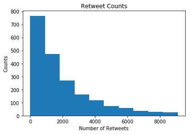

```python
limit = np.nanpercentile(twitter_archive_df_clean['retweet_count'], 95)
parameter = twitter_archive_df_clean['retweet_count'] < limit
data = twitter_archive_df_clean['retweet_count'][parameter]
plt.hist(data, bins = 10, range = [0, limit])
plt.title("Retweet Counts")
plt.xlabel("Number of Retweets")
plt.ylabel("Counts")
plt.show()
```

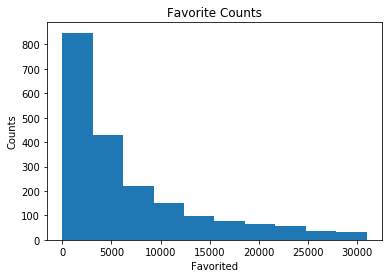

```python
limit = np.nanpercentile(twitter_archive_df_clean['favorite_count'], 95)
parameter = twitter_archive_df_clean['favorite_count'] < limit
data = twitter_archive_df_clean['favorite_count'][parameter]
plt.hist(data, bins = 10, range = [0, limit])
plt.title("Favorite Counts")
plt.xlabel("Favorited")
plt.ylabel("Counts")
plt.show()
```

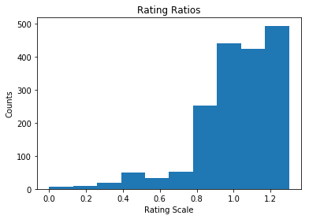

```python
limit = np.nanpercentile(twitter_archive_df_clean['rating'], 95)
parameter = twitter_archive_df_clean['rating'] < limit
data = twitter_archive_df_clean['rating'][parameter]
plt.hist(data, bins = 10, range = [0, limit])
plt.title("Rating Ratios")
plt.xlabel("Rating Scale")
plt.ylabel("Counts")
plt.show()
```

```python
twitter_archive_df_clean['probable_breed'].count() / len(twitter_archive_df_clean['probable_breed'])
```

```
0.7963137996219282
```

```python
twitter_archive_df_clean['probable_breed'].value_counts()[0:10]
```

```
Golden Retriever      157
Labrador Retriever    108
Pembroke               95
Chihuahua              91
Pug                    62
Toy Poodle             51
Chow                   48
Samoyed                42
Pomeranian             42
Malamute               33
Name: probable_breed, dtype: int64
```

```python
twitter_archive_df_clean['dog_stage'].value_counts().sum() / len(twitter_archive_df_clean['dog_stage'])
```

```
0.15689981096408318
```

```python
twitter_archive_df_clean['dog_stage'].value_counts().sum()
```

```
332
```

```python
twitter_archive_df_clean['dog_stage'].value_counts()
```

```
Pupper     224
Doggo       74
Puppo       24
Floofer     10
Name: dog_stage, dtype: int64
```

```python
twitter_archive_df_clean['source'].value_counts()
```

```
Twitter for iPhone     1984
Vine - Make a Scene      91
Twitter Web Client       30
TweetDeck                11
Name: source, dtype: int64
```